# Exponential and Normal Distributions

Applied Statistics

MTH-361A | Spring 2026 | University of Portland

# Objectives

- **Develop and understanding of the exponential distribution**
- **Develop and understanding of the normal distribution**
- **Know how to compute exponential and normal probabilities using R**
- **Introduce how to simulate exponential and normal random sampling in R**

# Visualizing The Exponential Distribution (1/2)

**Exponential Probability Density Function (PDF)**

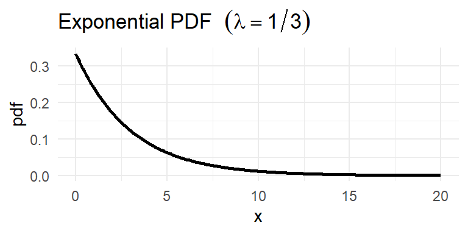

$\star$ The exponential r.v. has infinitely sized sample space. The plot of the exponential PDF only shows the range $0 \le x \le 20$.

**Exponential R.V. and PDF:**

Let $\lambda$ be the rate parameter.

- $\displaystyle X \sim \text{Exp}\left(\lambda\right)$
- $\displaystyle f(x) = \lambda e^{-\lambda x}, \quad x \ge 0$

**Relevant R Functions:**

- `dexp` $\leftarrow$ PDF
- `rexp` $\leftarrow$ random sampling simulation

# Visualizing The Exponential Distribution (2/2)

**Exponential Cumulative Density Function (CDF)**

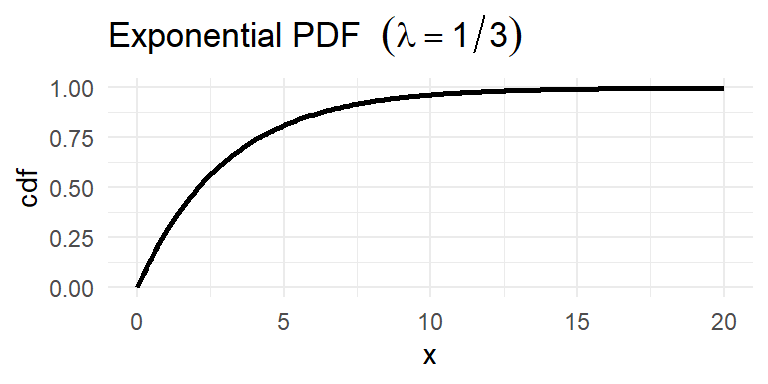

$\star$ The CDF, in general, computes the cumulative probability of a given PDF.

**Exponential PDF and CDF:**

Let $\lambda$ be the rate parameter.

- $\displaystyle f(x) = \lambda e^{-\lambda x}, \quad x \ge 0$
- $\displaystyle P(X \le x) = \int_{0}^{x} f(t) \ dt, \quad x \ge 0$

**Relevant R Functions:**

- `pexp` $\leftarrow$ CDF
- `qexp` $\leftarrow$ Inverse CDF

# Exponential Probabilities (1/2)

**Exponential Distribution:**

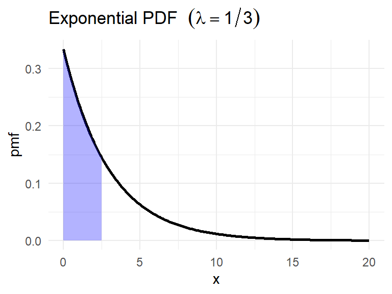

$\star$ Note that the `pexp` function computes the probability $P(X \le x)$, meaning it computes the area under the PDF from $X=0$ to $X=x$. The `dexp` function computes the density, not probability because $P(X = x) = 0$ at any $x$.

**Example:**

*What is the probability that “success” happens on 2.5 unit length or less, given $\lambda=\frac{1}{3}$?*
$$\begin{aligned}
P(X \le 2.5) & = \int_0^{2.5} f(t) \ dt \\
& = \int_0^{2.5} \frac{1}{3} e^{-\frac{1}{3} t} \ dt \\
P(X \le 2.5) & \approx 0.565
\end{aligned}$$

**Using R:**

```r
pexp(2.5,1/3)
```

```
## [1] 0.5654018
```

# Exponential Probabilities (2/2)

**Exponential Distribution:**

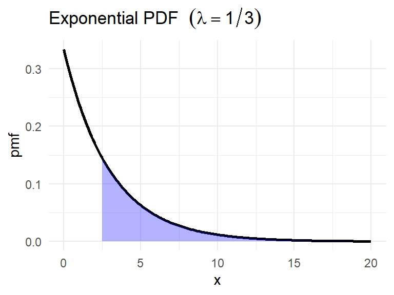

$\star$ Use the complement rule when computing the probability $P(X \ge x) = 1 - P(X \le x)$.

**Example:**

*What is the probability that “success” happens on at least 2.5 unit length, given $\lambda=\frac{1}{3}$?*
$$\begin{aligned}
P(X \ge 2.5) & = 1 - P(X \le 2.5) \\
& = 1 - \int_0^{2.5} f(t) \ dt \\
& = 1 - \int_0^{2.5} \frac{1}{3} e^{-\frac{1}{3} t} \ dt
\\
& = \int_{2.5}^{\infty} \frac{1}{3} e^{-\frac{1}{3} t} \
dt \\
P(X \ge 2.5) & \approx 0.435
\end{aligned}$$

**Using R:**

```r
1-pexp(2.5,1/3)
```

```
## [1] 0.4345982
```

# Exponential Interval Probabilities

**Exponential Distribution:**

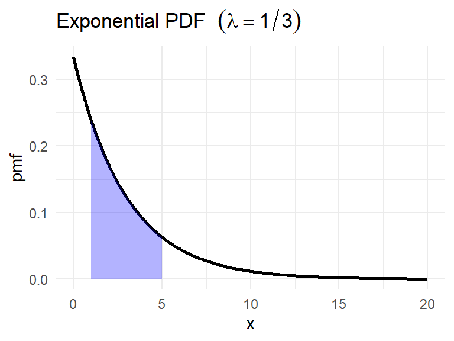

$\star$ Here, you need $P(1 \le X \le 5)$, which is equivalent to $P(X \le 5) - P(X \le 1)$. Since $P(X = 1) = 0$ and $P(X = 5) = 0$ for continuous r.v.s, we don’t worry about these cases when calculating interval probabilities.

**Example:**

*What is the probability that “success” happens between 1 to 5 unit length, given $\lambda=\frac{1}{3}$?*
$$\begin{aligned}
P(1 \le X \le 5) & = P(X \le 5) - P(X \le 1) \\
& = \int_0^{5} f(t) \ dt - \int_0^{1} f(t) \ dt \\
& = \int_1^{5} f(t) \ dt \\
& = \int_1^{5} \frac{1}{3} e^{-\frac{1}{3} t} \ dt \\
P(1 \le X \le 5) & \approx 0.528
\end{aligned}$$

**Using R:**

```r
pexp(5,1/3)-pexp(1,1/3)
```

```
## [1] 0.5276557
```

# Exponential Expected Value

**Exponential Distribution with Expected Value**

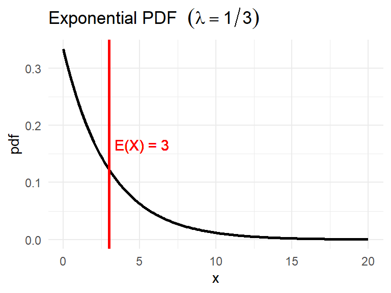

$\star$ The law of large numbers still can be used to interpret the expected value, which in this case, you would expect to have $3$ unit length until a “success” occurs in the long run.

**Exponential R.V.**

Let $\lambda=\frac{1}{3}$ be the rate parameter.

- $\displaystyle X \sim \text{Exp}\left(\frac{1}{3}\right)$
- $\displaystyle f(x) = \lambda e^{-\frac{1}{3} x}, \quad x \ge 0$
- $\displaystyle \text{E}(X) = 3$

In general,
$$\begin{aligned}
\text{E}(X) & = \int_0^{\infty} x f(x) \ dx \\
& = \int_0^{\infty} x \lambda e^{-\lambda x} \ dx \\
\text{E}(X) & = \frac{1}{\lambda}
\end{aligned}$$
which is the reciprocal of the rate parameter.

# Visualizing the Normal Distribution (1/2)

**Normal Probability Density Function (PDF)**

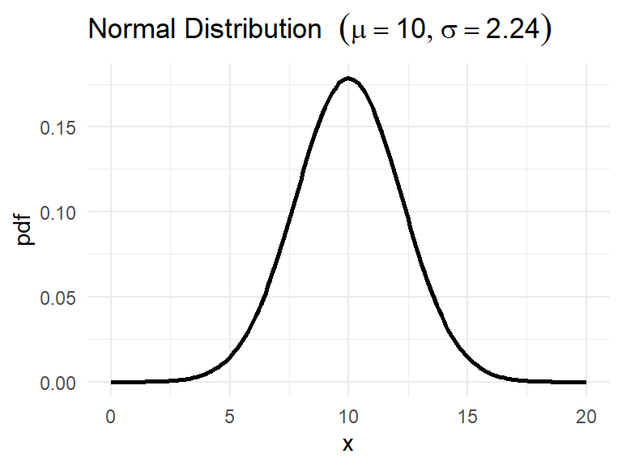

**Normal R.V. and PDF:**

Let $\mu$ be the mean and $\sigma^2$ be the variance.

- $\displaystyle X \sim \text{N}\left(\mu,\sigma^2\right)$
- $\displaystyle f(x) = \frac{1}{\sigma \sqrt{2 \pi}} \exp{\left(-\frac{1}{2} \left( \frac{x - \mu}{\sigma} \right)^2\right)}, \ -\infty < x < \infty$

**Relevant R Functions:**

- `dnorm` $\leftarrow$ PDF
- `rnorm` $\leftarrow$ random sampling simulation

# Visualizing the Normal Distribution (2/2)

**Normal Cumulative Density Function (CDF)**

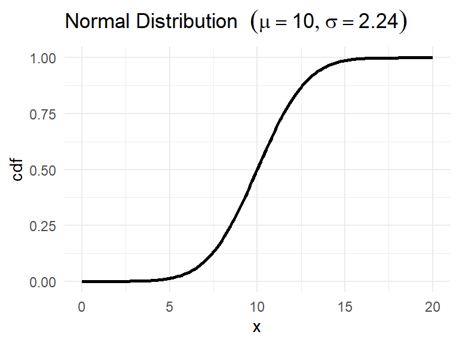

$\star$ The CDF of the Normal distribution is also known as the *sigmoid* function.

**Normal PDF and CDF:**

Let $\mu$ be the mean and $\sigma^2$ be the variance.

- $\displaystyle f(x) = \frac{1}{\sigma \sqrt{2 \pi}} \exp{\left(-\frac{1}{2} \left( \frac{x - \mu}{\sigma} \right)^2\right)}, \ -\infty < x < \infty$
- $\displaystyle P(X \le x) = \int_{\infty}^{x} f(t) \ dt$

**Relevant R Functions:**

- `pnorm` $\leftarrow$ CDF
- `qnorm` $\leftarrow$ Inverse CDF

# Normal Probabilities (1/2)

**Normal Distribution:**

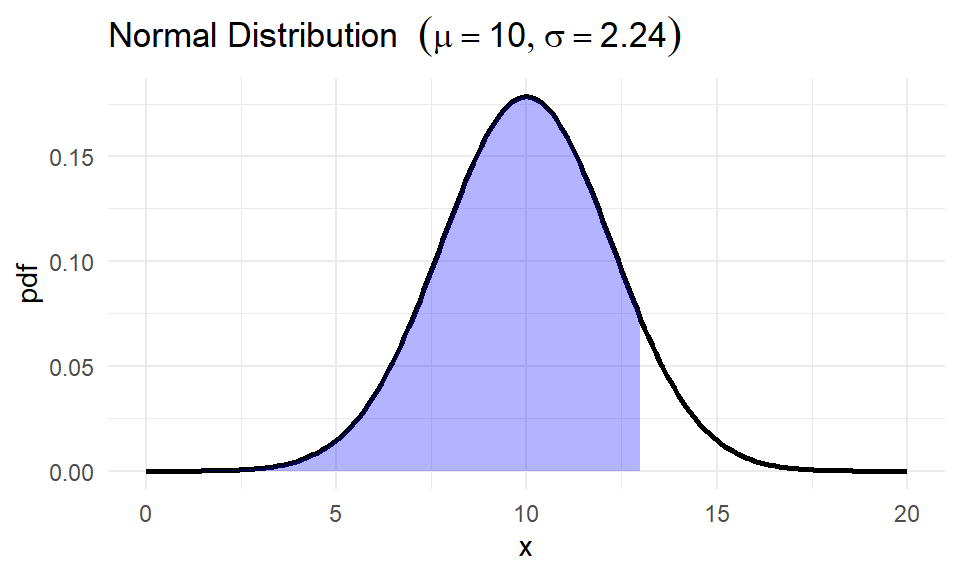

$\star$ Note that the `pnorm` function id the CDF, which computes the probability $P(X \le x)$, meaning it computes the area under $f(x)$, the PDF, from $-\infty$ to $X=x$. The `dnorm` function computes the density, not probability because $P(X = x)=0$ at any $x$.

**Example:**

*What is the probability that a randomly selected value is at most $13$?*

$$\begin{aligned}
P(X \le 13) & = \int_{-\infty}^{13} f(t) \ dt \\
& = \int_{-\infty}^{13} \frac{1}{2.24 \sqrt{2 \pi}}
\exp{\left(-\frac{1}{2} \left( \frac{t - 10}{2.24} \right)^2\right)} \
dt \\
P(X \le 13) & \approx 0.910
\end{aligned}$$

**Using R:**

```r
pnorm(13,10,2.24)
```

```
## [1] 0.9097612
```

# Normal Probabilities (2/2)

**Normal Distribution:**

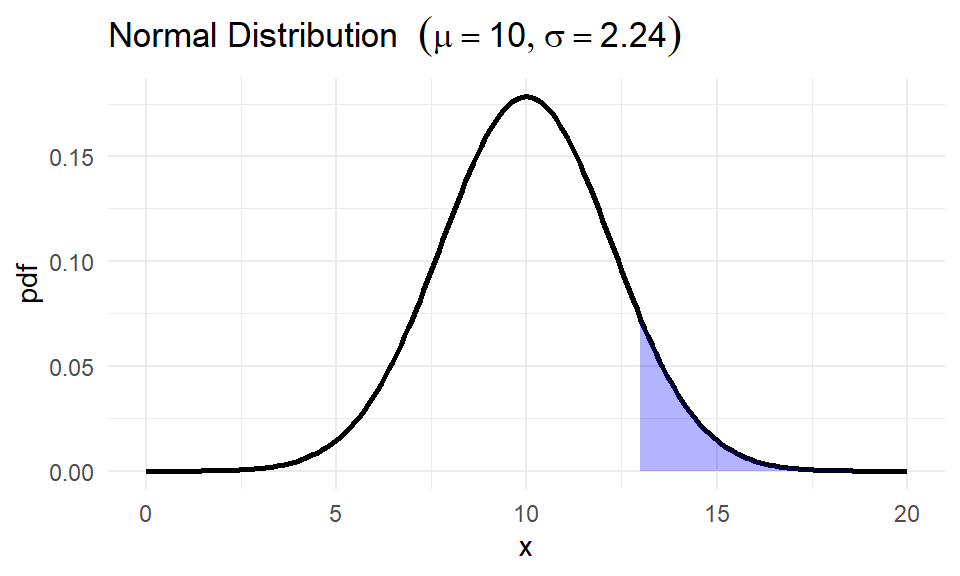

$\star$ Remember that there is no known anti-derivative to the normal PDF (also known as the Gaussian function). So, the integral here is evaluated using numerical approximations.

**Example:**

*What is the probability that a randomly selected value is at least $13$?*

**Using R:**

```r
1-pnorm(13,10,2.24)
```

```
## [1] 0.09023884
```

# Normal Interval Probabilities

**Normal Distribution:**

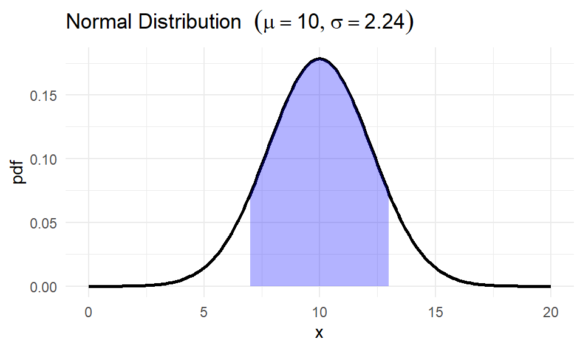

$\star$ Here, you need $P(7 \le X \le 13)$, which is equivalent to $P(X \le 13) - P(X \le 7)$. Since $P(X = 7) = 0$ and $P(X = 13) = 0$ for continuous r.v.s, we don’t worry about these cases when calculating interval probabilities.

**Example:**

*What is the probability that a randomly selected value is between $7$ and $13$?*

$$\begin{aligned}
P(7 \le X \le 13) & = P(X \le 13)-P(X \le 7) \\
& = \int_{-\infty}^{13} f(t) \ dt - \int_{-\infty}^{7}
f(t) \ dt \\
& = \int_{7}^{13} f(t) \ dt \\
& = \int_{7}^{13} \frac{1}{2.24 \sqrt{2 \pi}}
\exp{\left(-\frac{1}{2} \left( \frac{t - 10}{2.24} \right)^2\right)} \
dt \\
P(7 \le X \le 13) & \approx 0.820
\end{aligned}$$

**Using R:**

```r
pnorm(13,10,2.24)-pnorm(7,10,2.24)
```

```
## [1] 0.8195223
```

# Normal Expected Value

**Normal Distribution with Expected Value:**

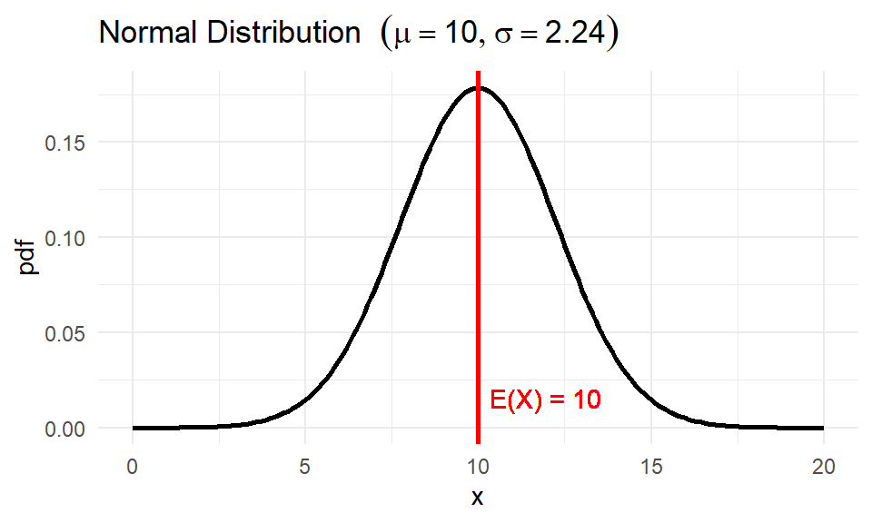

**Exponential R.V.**

Let $\mu = 10$ be the mean and $\sigma^2 = 2.24^2$ be the variance.

- $\displaystyle X \sim \text{N}\left(10,2.24^2\right)$
- $\displaystyle f(x) = \frac{1}{\sigma \sqrt{2 \pi}} \exp{\left(-\frac{1}{2} \left( \frac{x - \mu}{\sigma} \right)^2\right)}, \ -\infty < x < \infty$
- $\displaystyle \text{E}(X) = 10$

In general, the expected value of the normal r.v. is given by
$$\begin{aligned}
\text{E}(X) & = \int_{-\infty}^{\infty} x f(x) \ dx \\
& = \int_{-\infty}^{\infty} \frac{x}{\sigma \sqrt{2
\pi}} \exp{\left(-\frac{1}{2} \left( \frac{x - \mu}{\sigma}
\right)^2\right)} \ dx \\
\text{E}(X) & = \mu
\end{aligned}$$
which is the center of the normal distribution.

# The Normal Distribution is Symmetric

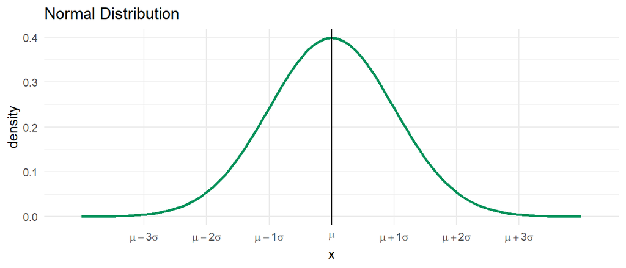

$\star$ The key property of the normal distribution is that it is symmetric about the mean $\mu$, meaning the probabilities are equal for each side.

# The 68-95-99.7 Rule (1/3)

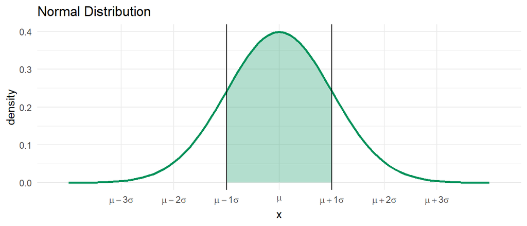

$$P(\mu - \sigma \le X \le \mu + \sigma)
\approx 0.68$$

# The 68-95-99.7 Rule (2/3)

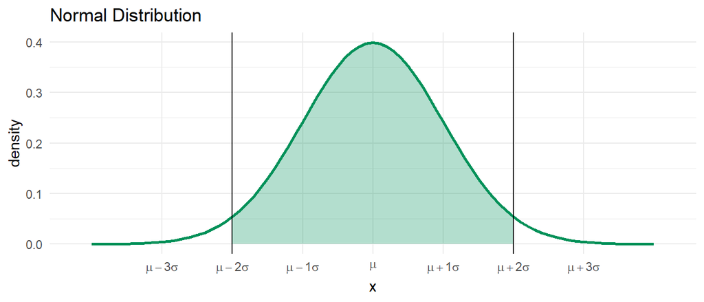

$$P(\mu - 2\sigma \le X \le \mu + 2\sigma)
\approx 0.95$$

# The 68-95-99.7 Rule (3/3)

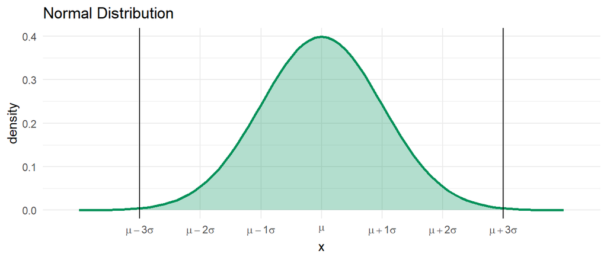

$$P(\mu - 3\sigma \le X \le \mu + 3\sigma)
\approx 0.997$$

# Total Area

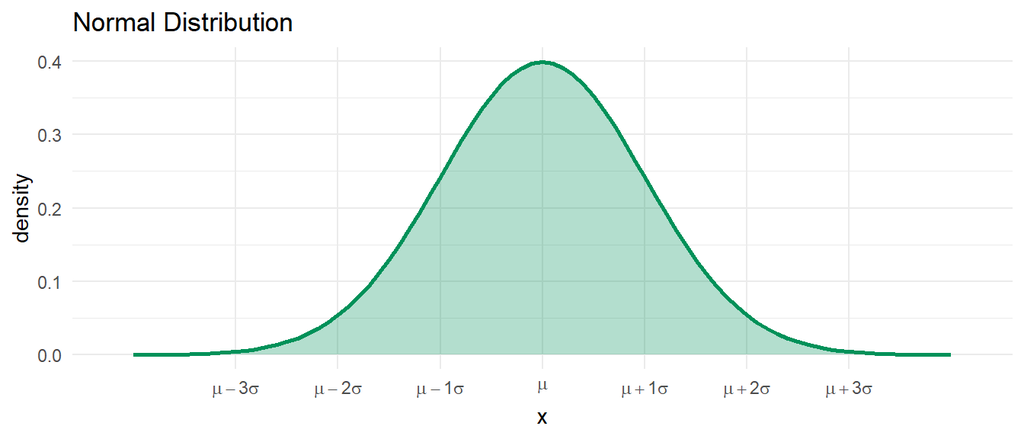

$$P(\mu - \infty \le X \le \mu + \infty) =
1$$

$\star$ Because of the axiom that the sum of the probabilities for all outcomes in the sample space is equal to 1, the total area under the Normal PDF is always 1.

# The Standard Normal Distribution

**The z-score formula:**

$$z = \frac{x - \mu}{\sigma}$$

**Standard Normal R.V. and PDF:**

Let $\mu = 0$ be the mean and $\sigma^2 = 1$ be the variance.

- $\displaystyle Z \sim \text{N}\left(0,1\right)$
- $\displaystyle f(z) = \frac{1}{\sqrt{2 \pi}} \exp{\left(-\frac{z^2}{2} \right)}; \\ \quad \text{ for } -\infty < z < \infty$

**How the transformation works:**

- Let $x = \mu$ and $\sigma = 1$.
- Then, $z = 0$, meaning the distance from the mean to itself is $0$ standard deviations.
- A positive z-score indicates the value is above the mean, while a negative z-score indicates it is below.

$\star$ The z-score $z$ is a measure on how many standard deviations a data point $x$ is from the mean $\mu$.

# Visualizing the Standard Normal Distribution

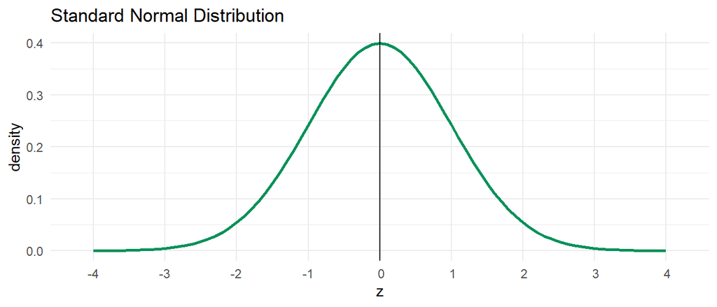

$\star$ The standard normal distribution serves as a reference distribution, allowing any normally distributed variable to be standardized.

# Summary of Continuous R.V.s and their Properties

|  | **Exponential** | **Normal** |
| --- | --- | --- |
| *Description* | Unit length until a “success” event happens | Approximation to the Binomial with sufficiently large number of $n$ independent Bernoulli trials |
| *Parameters* | $\lambda \longrightarrow$ rate of “success” | $\mu \longrightarrow$ mean $\sigma^2 \longrightarrow$ variance |
| $\displaystyle X$ | $\displaystyle \text{Exp}(\lambda)$ | $\displaystyle \text{N}(\mu,\sigma^2)$ |
| $\displaystyle \text{E}(X)$ | $\displaystyle \frac{1}{\lambda}$ | $\displaystyle \mu$ |
| $\displaystyle \text{Var}(X)$ | $\displaystyle \frac{1}{\lambda^2}$ | $\displaystyle \sigma^2$ |

$\star$ If you are approximating a Binomial distribution, set $\mu = np$ and $\sigma^2 = np(1-p)$.

$\star$ If you want the standard normal distribution set $\mu = 0$ and $\sigma = 1$.

# Summary of Continuous R.V.s and their PMFs

|  | **Exponential** | **Normal** |
| --- | --- | --- |
| $\displaystyle f(x)$ *PDF* | $\displaystyle \lambda e^{-\lambda x}$ $\text{for } x \ge 0$ | $\displaystyle \frac{1}{\sigma \sqrt{2 \pi}} \exp{\left(-\frac{1}{2} \left( \frac{x - \mu}{\sigma} \right)^2\right)}$ $\text{for }-\infty < x < \infty$ |
| *R PMF* | `dexp` | `dnorm` |
| *R CDF* | `pexp` | `pnorm` |
| *R Inverse CDF* | `qexp` | `qnorm` |
| *R Simulations* | `rexp` | `rnorm` |